# Intro to Visualization in Python - Static Plots - 3

One should look for what is and not what he thinks should be. (Albert Einstein)

# Module completion checklist

| Objective | Complete |
| --- | --- |
| Create violin plots |  |
| Create compound visualizations |  |

# Breakout Room Activity

- Read the article and check out the ten best data visualizations of 2021: [link](https://towardsdatascience.com/the-10-best-data-visualizations-of-2021-fec4c5cf6cdb)
- In breakout rooms, take 5 minutes to discuss **which ones did you find the most effective? Why?**
- Nominate a representative to share your group’s thoughts

[figure not shown]

# Course recap

# Complex univariate plots: violin plots

- Violin plots are primarily used to look at the **variations in the data**
- The characteristics of violin plots are similar to the box plot, except they **visualize the probability density** of the entire data
- Just like box plots, they include a marker that shows the median
- The violin plot has elongated projections when the density is high and flat projections when the probability density is low
- The attributes `showmeans` and `showmedians` can be set to true or false to show the mean/median and vice versa

```python
plt.violinplot(df_subset['DiabetesPedigreeFunction'],
               showmeans=False,
               showmedians=True)
```

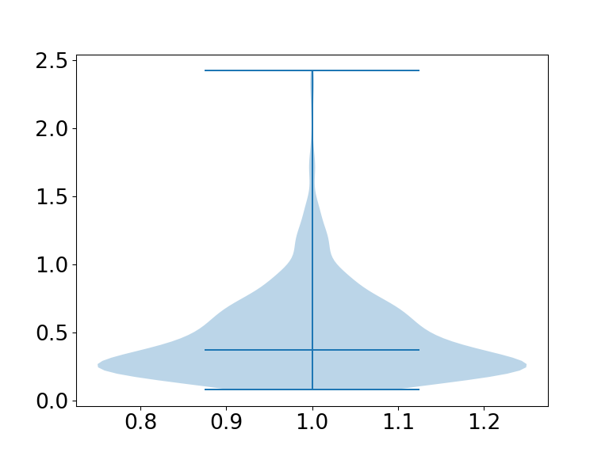

```python
plt.show()
```

# Univariate plots: violin plot interpretation

- The blue line in the middle shows the median of `'DiabetesPedigreeFunction'`
- The immediate areas around the median of the violin plot where the **probability density** is **higher** represent approximately the `25th` and `75th` percentile
- By comparing the box plot with the violin plot, It shows that the violin plot is a lot more helpful in understanding the exact probability distribution of data

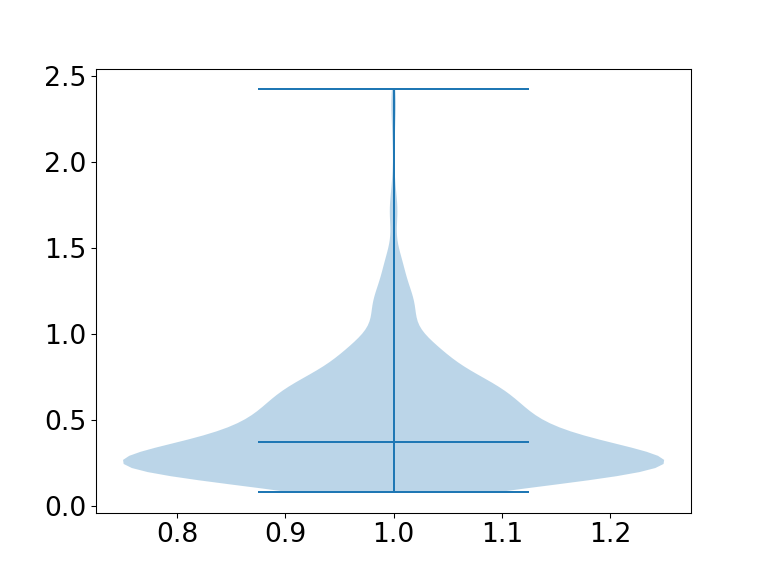

# Univariate plots: violin plot (cont’d)

- Change the orientation of the plot to horizontal by setting `vert = False`
- After looking at this violin plot, what can be told about the **`'DiabetesPedigreeFunction'` distribution** in our data?
- Share in the chat

```python
plt.violinplot(df_subset['DiabetesPedigreeFunction'], vert = False, showmeans=False, showmedians=True)
```

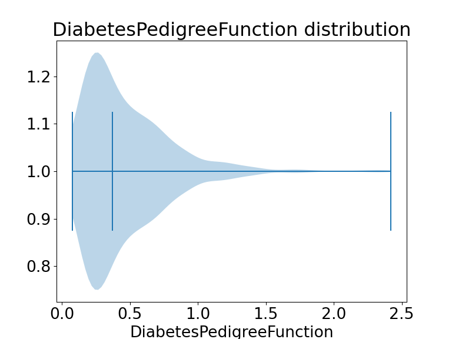

```python
plt.xlabel('DiabetesPedigreeFunction')
plt.title('DiabetesPedigreeFunction distribution')
plt.show()
```

# Module completion checklist

| Objective | Complete |
| --- | --- |
| Create violin plots | **✔** |
| Create compound visualizations |  |

# Compound visualizations: grids

- Create figures containing multiple plots laid out in a **grid** using `plt.subplots()`
- The `subplots` function returns two values, a **Figure** object, and an **Axes** object
  - Figure contains the entire grid and all of the elements inside
  - Axes is an array, where each member contains a particular subplot
- *Why do you think grid or compound visualizations are helpful?*
- *Where would you use such visualizations in your work?*

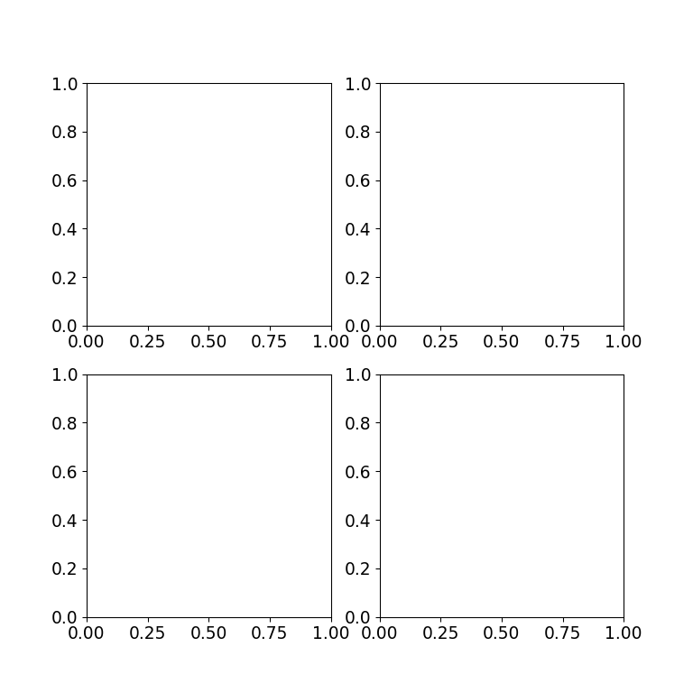

```python
# Create a 2 x 2 figure and axes grid.
fig, axes = plt.subplots(2, 2)
plt.show()
```

# Compound visualizations: axes

- `Axes` is just an array

```python
print(axes)
```

```
[[<Axes: > <Axes: >]
 [<Axes: > <Axes: >]]
```

- Since it’s a `2 x 2` grid, there is a 2D array with four entries that we will “fill” with values - that is, **plots**

# Compound visualizations: axes (cont’d)

- To access each element of the array, use a simple 2D array subsetting style `[row_id, col_id]`
- Instead of attaching a particular plot like a histogram, for example, to a `plt` object, attach it to the `axes[row_id, col_id]`

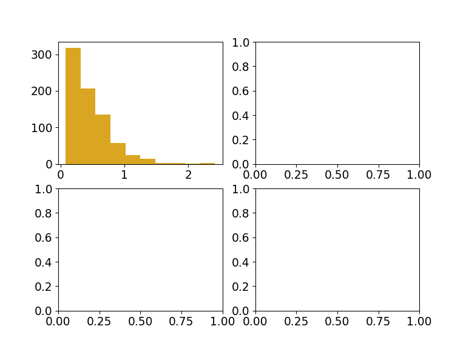

```python
plt.clf()
plt.figure(figsize = (8, 8))
plt.rcParams.update({'font.size': 14})
fig, axes = plt.subplots(2, 2)

axes[0, 0].hist(df_subset['DiabetesPedigreeFunction'],
                facecolor = 'goldenrod') #<- set color
```

# Compound visualizations: axes (cont’d)

- Fill out three remaining plots

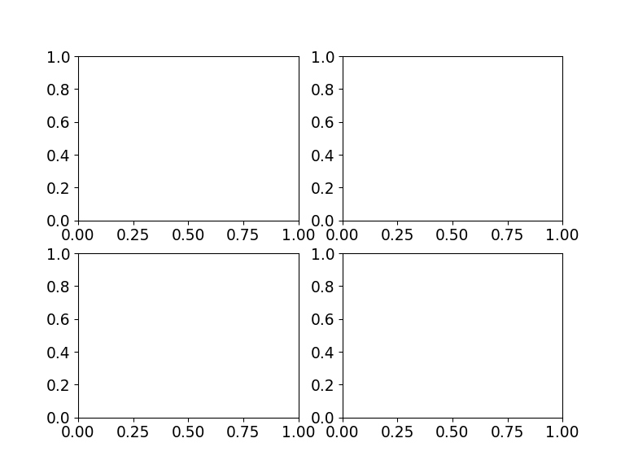

```python
plt.figure(figsize = (12, 8))
fig, axes = plt.subplots(2, 2)
color_dict = {int('0'): 'darkseagreen',
              int('1'): 'palevioletred'}
color = df_subset['Outcome'].map(color_dict)
```

```python
axes[0, 0].hist(df_subset['DiabetesPedigreeFunction'],
                facecolor = 'goldenrod') #<- set color
axes[0, 1].boxplot(df_subset['DiabetesPedigreeFunction'])
```

```
{'whiskers': [<matplotlib.lines.Line2D object at 0x407eedde10>, <matplotlib.lines.Line2D object at 0x407f4ba410>], 'caps': [<matplotlib.lines.Line2D object at 0x407f4bac90>, <matplotlib.lines.Line2D object at 0x407f4bb390>], 'boxes': [<matplotlib.lines.Line2D object at 0x407f437ad0>], 'medians': [<matplotlib.lines.Line2D object at 0x407f4bbcd0>], 'fliers': [<matplotlib.lines.Line2D object at 0x407f49f890>], 'means': []}
```

```python
axes[1, 0].scatter(df_subset['DiabetesPedigreeFunction'],
                   df_subset['Glucose'],
                   c = color,
                   alpha = 0.3)
axes[1, 1].bar(bar_positions, bar_heights,
               color = "salmon")
plt.show()
```

# Compound visualizations: labeling axes

- To label each plot’s axis, use `axes[row_id, col_id].set_xlabel` format

```python
# Histogram.
axes[0, 0].set_ylabel('DiabetesPedigreeFunction distribution')
axes[0, 0].set_xlabel('DiabetesPedigreeFunction')

# Boxplot.
axes[0, 1].set_ylabel('DiabetesPedigreeFunction')

# Scatterplot.
axes[1, 0].set_xlabel('DiabetesPedigreeFunction')
axes[1, 0].set_ylabel('Glucose')

# Mean values of categories of variable means.
axes[1, 1].set_ylabel('Mean values')
```

# Compound visualizations: labeling ticks

- To set ticks on each axis, use `axes[row_id, col_id].xaxis.set_ticks` format

```python
# No labels for ticks for boxplot.
axes[0, 1].xaxis.set_ticklabels([""])
```

```python
# Tick positions set to bar positions in bar chart.
axes[1, 1].xaxis.set_ticks(bar_positions)

# Tick labels set to bar categories in bar chart.
axes[1, 1].xaxis.set_ticklabels(bar_labels,rotation = 18)
```

# Compound visualizations: figure adjustments

- Make a few final adjustments to how our figure outputs

```python
plt.rcParams['axes.labelsize'] = 20
plt.rcParams['figure.titlesize'] = 25
fig.set_size_inches(18, 7.5)
fig.suptitle('Data Summary')
```

# Compound visualizations: putting it all together

- **Note:** The entire code block will be visible in your notebook

```python
plt.clf()
plt.figure(figsize = (8, 8))
plt.rcParams.update({'font.size': 14})
fig, axes = plt.subplots(2, 2)

color_dict = {int('0'): 'darkseagreen',
              int('1'): 'palevioletred'}
color = df_subset['Outcome'].map(color_dict)
axes[0, 0].hist(df_subset['SkinThickness'],
                facecolor = 'goldenrod') #<- set color
axes[0, 1].boxplot(df_subset['SkinThickness'])
axes[1, 0].scatter(df_subset['SkinThickness'],
                   df_subset['Glucose'],
                   c = color,
                   alpha = 0.3)
axes[1, 1].bar(bar_positions, bar_heights,
               color = "salmon")

# Histogram.
axes[0, 0].set_ylabel('SkinThickness distribution')
axes[0, 0].set_xlabel('SkinThickness')

# Boxplot.
axes[0, 1].set_ylabel('SkinThickness')

# Scatterplot.
axes[1, 0].set_xlabel('SkinThickness')
axes[1, 0].set_ylabel('Glucose')

# Mean values of categories of variable means.
axes[1, 1].set_ylabel('Mean values')

# No labels for ticks for boxplot.
axes[0, 1].xaxis.set_ticklabels([""])

# Tick positions set to bar positions in bar chart.
axes[1, 1].xaxis.set_ticks(bar_positions)

# Tick labels set to bar categories in bar chart.
axes[1, 1].xaxis.set_ticklabels(bar_labels,rotation = 18)

plt.rcParams['axes.labelsize'] = 20
plt.rcParams['figure.titlesize'] = 25
fig.set_size_inches(18, 7.5)
fig.suptitle('Data Summary')
plt.show()
```

# Compound visualizations: display the figure

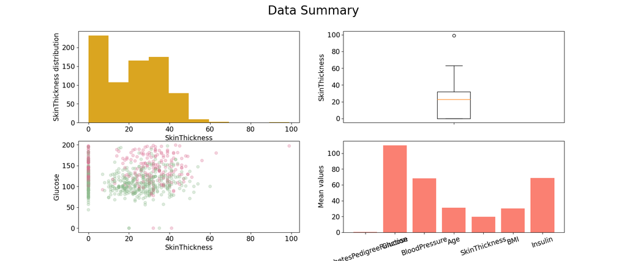

# Compound visualizations: layered plots

- Create figures containing multiple plots layered on top of each other using the same plotting area `plt.subplots()`
- Layered plots allow any number of plotting layers, making them very flexible - especially in those datasets where looking at patterns across multiple categories is essential

# Compound visualizations: layered plots (cont’d)

- Create a layered plot based on the scatterplot created earlier
- **Note:** The entire code block will be visible in your notebook

```python
plt.clf()                  #<- clear plotting area
fig, axes = plt.subplots() #<- create a new figure and axes objects for plotting

grouping_col_levels = list(df_grouped_mean_long[grouping_col].unique())
grouping_category_1 = grouping_col_levels[0]
grouping_category_2 = grouping_col_levels[1]

for key, value in color_dict.items():
    query = str('Outcome') + '==' + str(key)
    sc_col_1 = df_subset.query(query)['DiabetesPedigreeFunction']
    sc_col_2 = df_subset.query(query)['Glucose']

    if key == int(grouping_category_1):
        Flag = "Category 1"
    else:
        Flag = "Category 2"

    axes.scatter(sc_col_1,
                 sc_col_2,
                 c = value,
                 label = Flag,
                 alpha = 0.3)
axes.legend()  #<- add a legend that would automatically get labels and colors from layers!

plt.show()
```

# Compound visualizations: layered plots (cont’d)

- Layered scatterplot based on categories

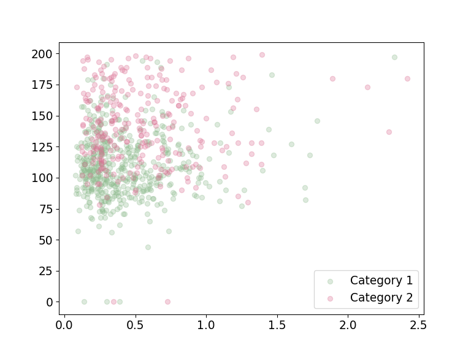

# Compound visualizations: layered plots (cont’d)

- Create a layered bar chart to visualize the mean values for each of the variables, based on both the `True` and `False` mean data

```python
# We already have `'Outcome'` = `'0'` mean data.
print(df_true_means.head())
```

```
                     metric        mean
0  DiabetesPedigreeFunction    0.429734
2                   Glucose  109.980000
4             BloodPressure   68.184000
6                       Age   31.190000
8             SkinThickness   19.664000
```

```python
# Let's get the `'Outcome'` = `'1'` mean data.
query = str('Outcome') + '==' + str('1')
df_false_means = df_grouped_mean_long.query(query)[['metric','mean']]
print(df_false_means)
```

```
                      metric        mean
1   DiabetesPedigreeFunction    0.550500
3                    Glucose  141.257463
5              BloodPressure   70.824627
7                        Age   37.067164
9              SkinThickness   22.164179
11                       BMI   35.142537
13                   Insulin  100.335821
```

# Compound visualizations: layered plots (cont’d)

```python
# Mean values for `'Outcome'` = `'0'` data.
category_1_bar_heights = df_true_means['mean']
# Mean values for `'Outcome'` = `'1'` data.
category_2_bar_heights = df_false_means['mean']
# Labels of bars, their width, and positions are shared for both categories.
bar_labels = df_false_means['metric']
num_bars = len(bar_labels)
bar_positions = np.arange(num_bars)
width = 0.35
```

# Compound visualizations: layered plots (cont’d)

```python
# Clear the plotting area for the new plot.
plt.clf()
# Create the figure and axes objects.
fig, axes = plt.subplots()
```

```python
category_1_bar_chart = axes.bar(bar_positions,          #<- set bar positions
                            category_1_bar_heights,     #<- set bar heights
                            width,                 #<- set width of the bars
                            color = color_dict[0]) #<- set color corresponding to '0' in dictionary
```

```python
category_2_bar_chart = axes.bar(bar_positions + width, #<- set bar positions
                          category_2_bar_heights,      #<- set bar heights
                          width,                 #<- set width of the bars
                          color = color_dict[1]) #<- set color corresponding to '1' in dictionary
```

# Compound visualizations: layered plots (cont’d)

```python
# Add text for labels, title and axes ticks.
axes.set_ylabel('Mean values')
axes.set_title('Data metrics summary')
axes.set_xticks(bar_positions + width/2)
axes.set_xticklabels(bar_labels)
```

# Compound visualizations: layered plots (cont’d)

- **Note:** The entire code block will be visible in your notebook

```python
# Clear the plotting area for the new plot.
plt.clf()
# Create the figure and axes objects.
fig, axes = plt.subplots()

category_1_bar_chart = axes.bar(bar_positions,          #<- set bar positions
                            category_1_bar_heights,     #<- set bar heights
                            width,                 #<- set width of the bars
                            color = color_dict[0]) #<- set color corresponding to '0' in dictionary
category_2_bar_chart = axes.bar(bar_positions + width, #<- set bar positions
                          category_2_bar_heights,      #<- set bar heights
                          width,                 #<- set width of the bars
                          color = color_dict[1]) #<- set color corresponding to '1' in dictionary

# Add text for labels, title and axes ticks.
axes.set_ylabel('Mean values')
axes.set_title('Data metrics summary')
axes.set_xticks(bar_positions + width/2)
axes.set_xticklabels(bar_labels)

# Add a legend for each chart and corresponding labels.
axes.legend((category_1_bar_chart, category_2_bar_chart), (f'{grouping_category_1}', f'{grouping_category_2}'))
fig.set_size_inches(12, 4)
plt.show()
```

# Compound visualizations: layered plots (cont’d)

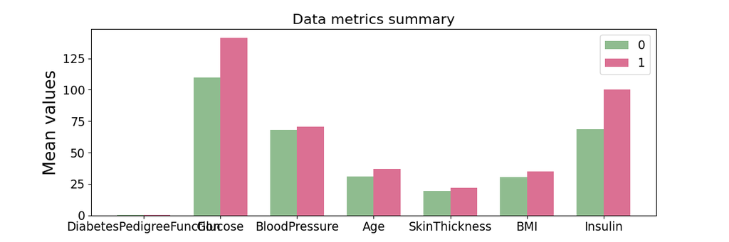

# Module completion checklist

| Objective | Complete |
| --- | --- |
| Create violin plots | **✔** |
| Create compound visualizations | **✔** |

# Knowledge check

# Exercise

[figure not shown]

You are now ready to try tasks 19-24 in the Exercise for this topic.

# Congratulations on completing this module!